# Day 09 - Lab : Bayesian Inference Solutions

For this lab we will be working exercises from the Bayes Rules Book [Chapter 3](https://www.bayesrulesbook.com/chapter-3#exercises-2) and [Chapter 8](https://www.bayesrulesbook.com/chapter-8#exercises-7).

````markdown
```{r}
library(bayesrules)
```
````

## Exercise 3.9 (Interpreting priors)

What do you call a sweet carbonated drink: pop, soda, coke, or something else? et $\pi$ be the proportion of U.S. residents that prefer the term “pop.” Two different beverage sales people from different regions of the country have different priors for $\pi$.

- The first salesperson works in North Dakota and specifies a Beta(8,2) prior.
- The second works in Louisiana and specifies a Beta(1,20) prior.
- Calculate the prior mean, median standard deviation of $\pi$ for both salespeople.

Monte Carlo method

````markdown
```{r}
library(tidyverse)
```
```{r}
# For the North Dakota salesperson

nd_prior_samples <- rbeta(10000,8,2)
la_samples <- rbeta(10000,1,20)


prior_df <- data.frame(
  ND = nd_prior_samples,
  LA = la_samples
) |> pivot_longer(cols = c(ND,LA),names_to="state")
```
````

````markdown
```{r}
prior_df |>
  group_by(state) |>
  summarize(
    mean_dist = mean(value),
    median_dist = median(value),
    sd_dist = sd(value)
  ) |> mutate(across(is.numeric,round,3))
```
````

```
# A tibble: 2 × 4
  state mean_dist median_dist sd_dist
  <chr>     <dbl>       <dbl>   <dbl>
1 LA        0.048       0.034   0.045
2 ND        0.799       0.82    0.12
```

- Plot the prior pdfs for both salespeople.

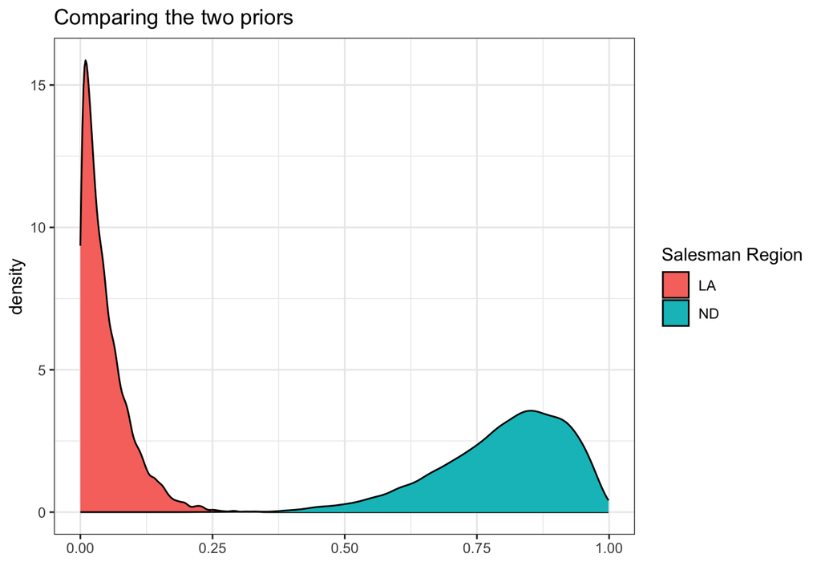

````markdown
```{r}
ggplot(prior_df) +
  geom_density(aes(value,group=state,fill=state))+
  scale_fill_discrete(name="Salesman Region") +
  xlab("") +
  ggtitle("Comparing the two priors") +
  theme_bw()
```
````

- Compare, in words, the salespeople’s prior understandings about the proportion of U.S. residents that say “pop.”

Salesman from ND has a prior that places more mass on large pct of people using name pop.

## Exercise **3.16 (Plotting the Beta-Binomial: Take I)**

[Refer to the website of the textbook](https://www.bayesrulesbook.com/chapter-3#exercises-2) to see the output from `plot_beta_binomial()` function. (Exercise 3.16).

**a)** Describe and compare both the prior model and likelihood function in words.

**b)** Describe the posterior model in words. Does it more closely agree with the data (as reflected by the likelihood function) or the prior?

**c)** Provide the specific `plot_beta_binomial()` code you would use to produce a similar plot. (Recall you can always use `?plot_beta_binomial` to get to the help page of the function).

## Exercise 3.16 (Solutions)

a) Prior has more density closer to 1, and smaller variance.

b) Posterior has larger variance like the data (likelihood), but the center of the distribution is between the two.

c)

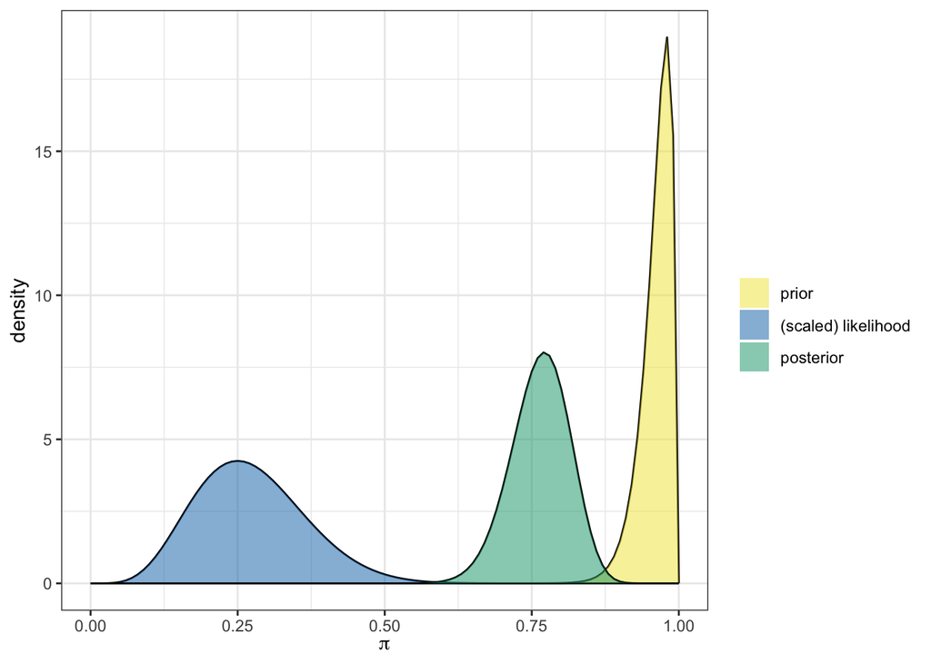

````markdown
```{r}
plot_beta_binomial(
  alpha=50,
  beta=2,
  y = 5,
  n = 20
) + theme_bw()
```
````

## Exercise 3.18 (More Beta-Binomial)

**a**) Patrick has a Beta(3,3) prior for $\pi$, the probability that someone in their town attended a protest in June 2020. In their survey of 40 residents, 30 attended a protest. Summarize Patrick’s analysis using `summarize_beta_binomial()` and `plot_beta_binomial()`.

**b)** Harold has the same prior as Patrick, but lives in a different town. In their survey, 15 out of 20 people attended a protest. Summarize Harold’s analysis using `summarize_beta_binomial()` and `plot_beta_binomial()`.

**c)** How do Patrick and Harold’s posterior models compare? Briefly explain what causes these similarities and differences.

## Exercise 3.18 (Solutions)

$$\pi \sim Beta(3, 3)$$

### a

```
      model alpha beta      mean      mode         var        sd
1     prior     3    3 0.5000000 0.5000000 0.035714286 0.1889822
2 posterior    33   13 0.7173913 0.7272727 0.004313639 0.0656783
```

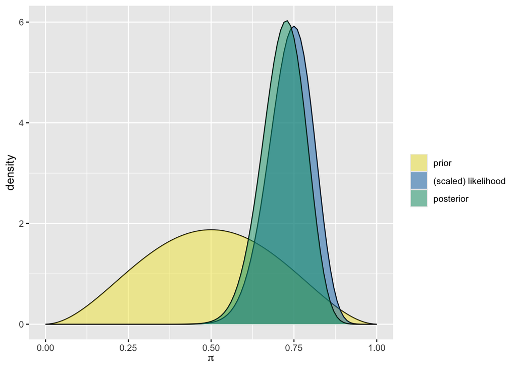

````markdown
```{r}
summarize_beta_binomial(
  alpha = 3,
  beta = 3,
  y = 30,
  n = 40
)

plot_beta_binomial(
  alpha = 3,
  beta = 3,
  y = 30,
  n = 40
)
```
````

**b)**

```
      model alpha beta      mean      mode         var         sd
1     prior     3    3 0.5000000 0.5000000 0.035714286 0.18898224
2 posterior    18    8 0.6923077 0.7083333 0.007889546 0.08882312
```

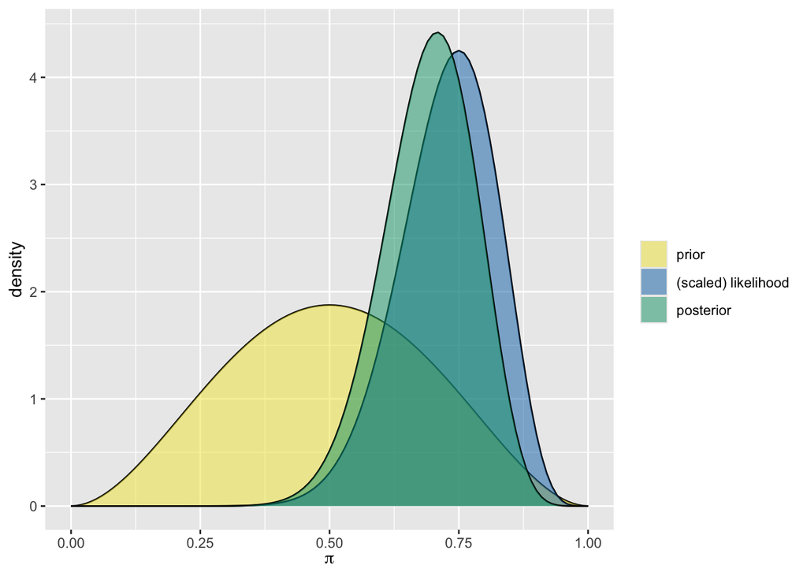

````markdown
```{r}
summarize_beta_binomial(
  alpha = 3,
  beta = 3,
  y = 15,
  n = 20
)

plot_beta_binomial(
  alpha = 3,
  beta = 3,
  y = 15,
  n = 20
)
```
````

**c**) Patrick’s and Harold’s posteriors are similar, but Patrick’s posterior is slightly more similar to the likelihood than the prior. This is because there was more data in Patrick’s town so the posterior was pulled closer to the likelihood and is narrower than Harold’s for this reason.

## Exercise 8.6 (Credible intervals: Part I)

For each situation, find the appropriate credible interval using the “middle” approach.

1. A 95% credible interval for $\pi$ with $\pi | y \sim Beta(4,5)$,

````markdown
```{r}
qbeta(c(0.025,0.975),4,5)
```
````

```
[1] 0.1570128 0.7551368
```

2. A 60% credible interval for $\pi$ with $\pi | y \sim Beta(4,5)$

   ````markdown
   ```{r}
   qbeta(c(0.20,0.80),4,5)
   ```
   ````

   ```
   [1] 0.3032258 0.5836554
   ```

3. A 95% credible interval for $\lambda$ with $\lambda|\gamma \sim Gamma(1,8)$

````markdown
```{r}
qgamma(c(0.025,0.975),1,8)
```
````

```
[1] 0.003164726 0.461109932
```

## Exercise 8.9 (Hypothesis tests: Part I)

For parameter $\pi$ , suppose you have a $Beta(1,0.8)$ prior model and a $Beta(4,3)$ posterior.

You wish to test the null hypothesis that $\pi \leq 0.4$ versus the alternative that $\pi>0.4$ .

Answer the following questions:

**a)**: What is the posterior probability for the alternative hypothesis?

**b)** Calculate and interpret the posterior odds. **c)** Calculate and interpret the prior odds. **d)** Calculate and interpret the Bayes Factor. **e)** Putting this together, explain your conclusion about these hypotheses to someone who is unfamiliar with Bayesian statistics.

## Exercise 8.9 Solutions

$$\pi \sim Beta(1, 0.8), \pi | Y \sim(4, 3)$$

$$H_0: \pi \leq 0.4, H_A: \pi > 0.4$$

**a)**

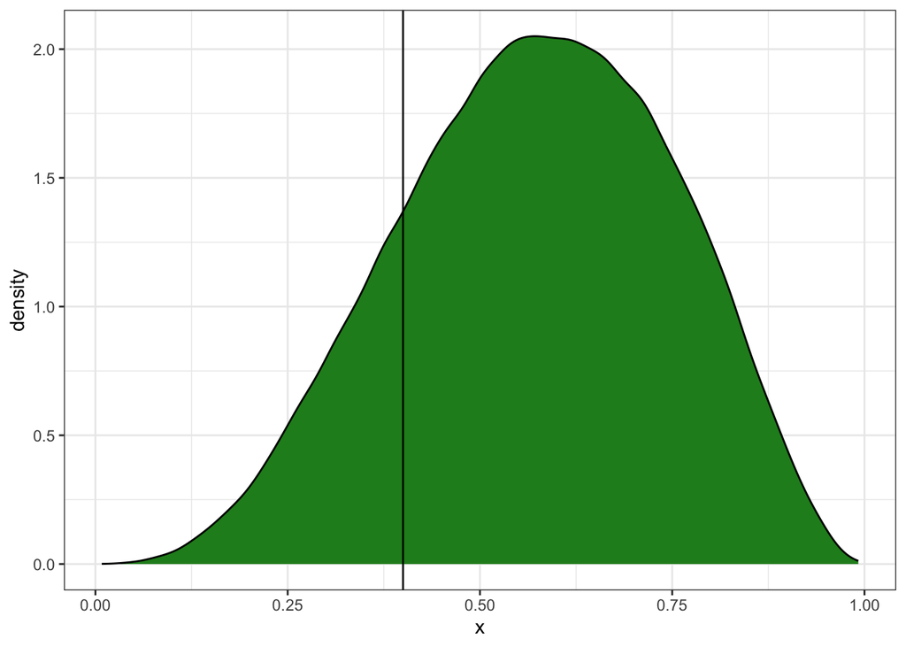

````markdown
```{r}
ggplot(data=data.frame(x=rbeta(100000,4,3))) + geom_density(aes(x=x),fill="forestgreen") + theme_bw() + geom_vline(xintercept = 0.4)
```
````

````markdown
```{r}
1 - pbeta(0.4, 4, 3)
```
````

```
[1] 0.8208
```

**b)**

````markdown
```{r}
posterior_odds <- (1 - pbeta(0.4, 4, 3)) / pbeta(0.4, 4, 3)
posterior_odds
```
````

```
[1] 4.580357
```

After having observed the data, the alternative hypothesis is 4.6 times more probable than the null hypothesis

**c)**

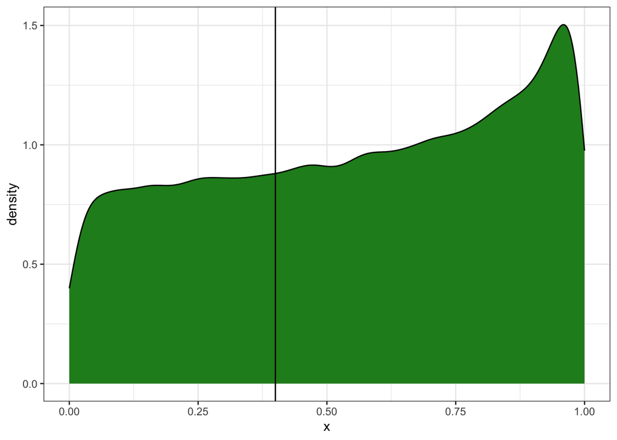

````markdown
```{r}
ggplot(data=data.frame(x=rbeta(100000,1,0.8))) + geom_density(aes(x=x),fill="forestgreen") + theme_bw() + geom_vline(xintercept = 0.4)
```
````

````markdown
```{r}
prior_odds <- (1 - pbeta(0.4, 1, 0.8)) / pbeta(0.4, 1, 0.8)

prior_odds
```
````

```
[1] 1.98098
```

Before observing the data, the alternative hypothesis is 1.98 times more probable than the null hypothesis.

**d)**

````markdown
```{r}
posterior_odds / prior_odds
```
````

```
[1] 2.312168
```

The plausibility of the alternative hypothesis increased by a factor of 2.31 in light of the observed data.

**e)** The Bayes Factor (BF) compares the posterior odds to the prior odds, and hence provides insight into just how much our understanding evolved upon observing our sample data: Since the Bayes factor is greater than 1, specifically 2.3, we conclude that our belief in $\pi > 0.4$ has more than doubled after having observed the data.

## Exercise 4.15 (One at the time)

Let $\pi$ be the probability of success for some event of interest. You place a Beta(2, 3) prior on $\pi$ and are really impatient. Sequentially update your posterior for $\pi$ with each new observation below. Between each run you also update your prior.

1. First observation: Success
2. Second observation: Success
3. Third observation: Failure
4. Fourth observation: Success

## Exercise 4.15 Solutions

First observation (success)

```
      model alpha beta mean      mode        var        sd
1     prior     2    3  0.4 0.3333333 0.04000000 0.2000000
2 posterior     3    3  0.5 0.5000000 0.03571429 0.1889822
      model alpha beta mean      mode        var        sd
1     prior     2    3  0.4 0.3333333 0.04000000 0.2000000
2 posterior     3    3  0.5 0.5000000 0.03571429 0.1889822
```

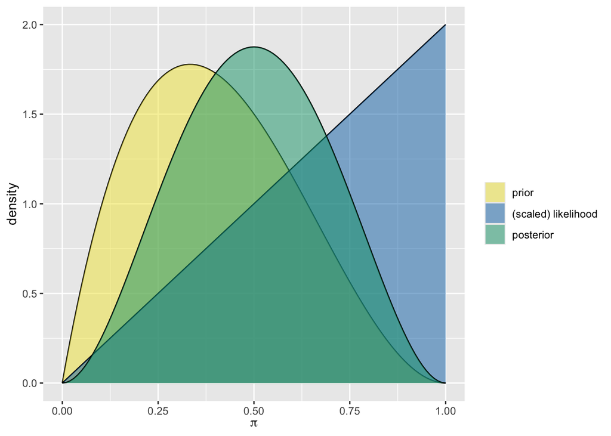

````markdown
```{r}
(res1 <- summarize_beta_binomial(
  alpha=2,
  beta=3,
  y = 1,
  n =1
))
plot_beta_binomial(
  alpha=2,
  beta=3,
  y = 1,
  n =1
)
res1
```
````

Second observation (success)

````markdown
```{r}
(res2 <- summarize_beta_binomial(
  alpha=res1 |> filter(model=="posterior") |> pull(alpha),
  beta= res1 |> filter(model=="posterior") |> pull(beta),
  y=1,
  n=1
))
```
````

```
      model alpha beta      mean mode        var        sd
1     prior     3    3 0.5000000  0.5 0.03571429 0.1889822
2 posterior     4    3 0.5714286  0.6 0.03061224 0.1749636
```

Third observation: Failure

````markdown
```{r}
(res3 <- summarize_beta_binomial(
  alpha=res2 |> filter(model=="posterior") |> pull(alpha),
  beta=res2 |> filter(model=="posterior") |> pull(beta),
  y = 0,
  n =1 ))
```
````

```
      model alpha beta      mean mode        var        sd
1     prior     4    3 0.5714286  0.6 0.03061224 0.1749636
2 posterior     4    4 0.5000000  0.5 0.02777778 0.1666667
```

Fourth observation: Success

```
      model alpha beta      mean      mode        var        sd
1     prior     4    4 0.5000000 0.5000000 0.02777778 0.1666667
2 posterior     5    4 0.5555556 0.5714286 0.02469136 0.1571348
```

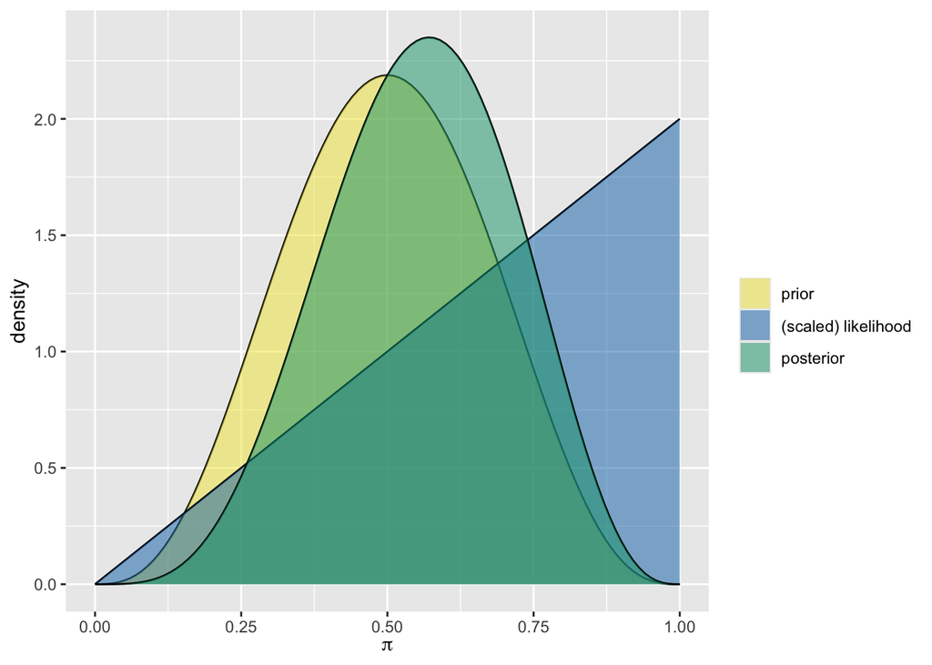

````markdown
```{r}
(res4 <- summarize_beta_binomial(
  alpha=res3 |> filter(model=="posterior") |> pull(alpha),
  beta=res3 |> filter(model=="posterior") |> pull(beta),
  y = 1, n =1 )
)

plot_beta_binomial(
  alpha=res3 |> filter(model=="posterior") |> pull(alpha),
  beta = res3 |> filter(model=="posterior") |> pull(beta),
  y=1,
  n=1
)
```
````

````markdown
```{r}
summarize_beta_binomial(
  alpha=2,
  beta=3,
  y=3,
  n=4
)
```
````

```
      model alpha beta      mean      mode        var        sd
1     prior     2    3 0.4000000 0.3333333 0.04000000 0.2000000
2 posterior     5    4 0.5555556 0.5714286 0.02469136 0.1571348
```